[figure not shown]

Monte Carlo Integration

estimate I.

The results of the methods will be both numerically and visually demonstrated in the next part.

1.1) Regular Monte Carlo

The regular Monte Carlo method, known for its simplicity, was executed as a first approach. This

method is a straightforward implication to give us an approximate idea of the estimated result.

Without large n values, it lacks precision. Also, as the functions get more complicated, they can

produce a high variance. To give a numeric understanding of the regular Monte Carlo for

estimation, the method is run once with n=1000, which resulted in the following:

Î = 55.47978

Vâr(Î) = 0.352643

1.2) Importance Sampling

Importance Sampling is a tricky technique that can either increase the precision by order of

Using neither of the parts could possibly yield more precision. However, we will require the part

to be PDF, which means the integral should sum up to 1.

The inverse cdf theorem is used to create a random generator of x where x follows a g

distribution.

[figure not shown]

Again, to understand the difference briefly, with n = 1000, I is estimated.

Î = 56.60613

Vâr(Î) = 0.07573875

1.3) Stratified Sampling

With importance sampling, there is an indication of improvement. And, as we have theoretically

proved in class, we guarantee better or equal precision by implementing stratified sampling.

Hence, we would expect an improvement during the simulation study as each method is

implemented.

Moreover, stratified sampling helps with precision by dividing the defined intervals into

subsections.

sample size allocation formula.

Stratified Sampling – Regular Monte Carlo

Î = 56.40815

Vâr(Î) = 0.02797143

Stratified Sampling – Importance Sampling

Î = 56.28738

Vâr(Î) = 0.008956549

Furthermore, although estimated I is not precise for both techniques, there is a dramatic decrease

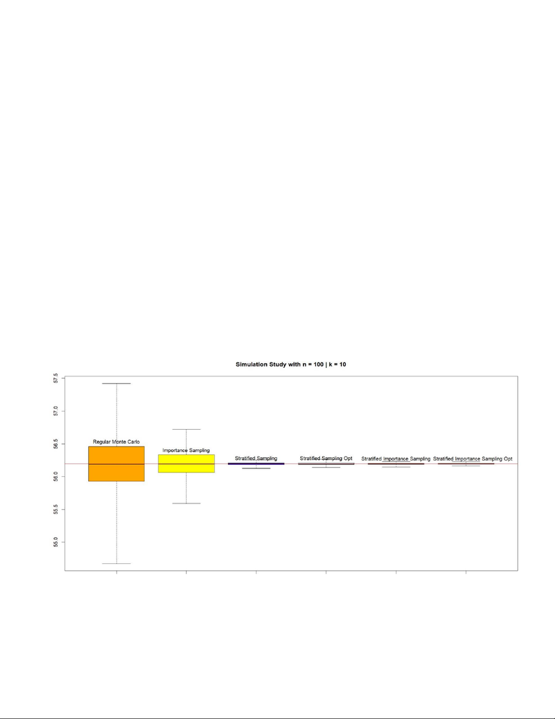

The challenging part about the optimization is that the standard deviation is unknown. Thus, by

among each subsection. As a result, the following estimations are found.

Stratified Sampling – Regular Monte Carlo

Î = 56.26408

Vâr(Î) = 0.02725889

Stratified Sampling – Importance Sampling

Î = 56.33721

Vâr(Î) = 0.006563842

We can observe a slight improvement as we proceed with each process. The next section will

discuss visual comparison of the methods in more depth.

2.1) Simulation Study

As there is a random component, even running the methods several times would not provide a

clear, trustful outcome. Hence, a simulation study is a great way to examine the underlying

The plot supports our intuition of smaller variance as the method proceeds. Our chosen g

function appears to decrease the variation dramatically as we go from regular Monte Carlo to

Importance Sampling. Also, the stratification method substantially increases the precision, and

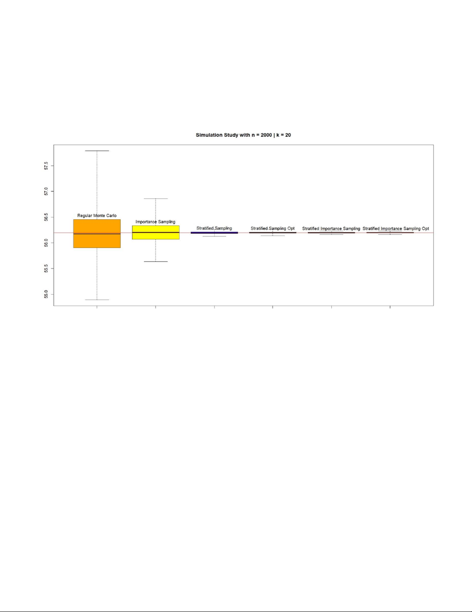

the optimized version has a small but effective impact on the estimation. Hence, we can observe

that regular Monte Carlo has the higher result deviation, whereas stratified importance

optimized sampling has the smallest. Lastly, all of the implementations appear to constitute the

theoretical value in the middle successfully.

Now let’s observe under the scope of greater n and k, 2000 and 20, respectively.

The gap for the regular Monte Carlo tilted upwards slightly. However, other than that, there is no

dramatic change as we go from n = 100 & k = 10 to n = 2000 & k = 20.

In conclusion, by choosing the g distribution carefully, we have successfully decreased the

variance and observed the significant impact that stratified sampling can have with simple

coding. However, particularly for this example, going from stratified sampling to optimized

stratified sampling did not have a major improvement. Therefore, the optimization of the sample

size allocation might not be implemented in the cases that are harder to achieve.

[figure not shown]